# Evaluación del desempeño de modelos en R

# 1. Introducción

- El desempeño de un modelo puede evaluarse de varias formas. La más obvia es la **precisión**, pero puede ser engañosa.
- Veremos en detalle la matriz de confusión, el estadístico kappa, la sensibilidad y la especificidad, la curva ROC y el área AUC, y la validación cruzada.
- Tanto para medir un modelo en términos absolutos como para compararlo con otros.

# 2. Datos

- Volvemos a los datos del banco portugués: queremos predecir si una persona adquiere el depósito a plazo (`y`) que se le ofrece por teléfono.
- Para que el taller corra ágil en clase, usamos una **muestra de 5.000 clientes** de la base original (ver nota al final). Leemos con `stringsAsFactors = TRUE`:

```r
bank <- read.csv("data/bank.csv", stringsAsFactors = TRUE)
```

- Dividamos en entrenamiento (90%) y prueba (10%), fijando la semilla:

```r
set.seed(123)
train_sample <- sample(nrow(bank), 0.9 * nrow(bank))
bank_train <- bank[train_sample, ]
bank_test  <- bank[-train_sample, ]
```

- Estimemos un árbol de decisión (C5.0) y pronostiquemos sobre la base de prueba:

```r
library(C50)
bank_tree <- C5.0(bank_train[-20], bank_train$y)
bank_pred_tree <- predict(bank_tree, bank_test)
```

# 3. Matriz de confusión y precisión total

- Construimos la matriz de confusión con `CrossTable()` del paquete `gmodels`:

```r
library(gmodels)
CrossTable(bank_test$y, bank_pred_tree, prop.chisq = FALSE, prop.c = FALSE, prop.r = FALSE,
           dnn = c("Real", "Pronóstico"))
```

```
##
##
##    Cell Contents
## |-------------------------|
## |                       N |
## |         N / Table Total |
## |-------------------------|
##
##
## Total Observations in Table:  500
##
##
##              | Pron'ostico
##         Real |        no |       yes | Row Total |
## -------------|-----------|-----------|-----------|
##           no |       407 |        30 |       437 |
##              |     0.814 |     0.060 |           |
## -------------|-----------|-----------|-----------|
##          yes |        37 |        26 |        63 |
##              |     0.074 |     0.052 |           |
## -------------|-----------|-----------|-----------|
## Column Total |       444 |        56 |       500 |
## -------------|-----------|-----------|-----------|
##
##
```

# 4. Otras medidas de desempeño

- Con el paquete `caret` accedemos a un conjunto rico de medidas. Si no lo tienes instalado:

```r
install.packages("caret")
```

- La función `confusionMatrix()` calcula la matriz y muchas medidas. Es importante indicar cuál clase es el “positivo” (aquí, `"yes"`: que sí compra). El primer argumento son las predicciones y el segundo la realidad:

```r
library(caret)
confusionMatrix(data = bank_pred_tree, reference = bank_test$y, positive = "yes")
```

```
## Confusion Matrix and Statistics
##
##           Reference
## Prediction  no yes
##        no  407  37
##        yes  30  26
##
##                Accuracy : 0.866
##                  95% CI : (0.833, 0.8946)
##     No Information Rate : 0.874
##     P-Value [Acc > NIR] : 0.7314
##
##                   Kappa : 0.3612
##
##  Mcnemar's Test P-Value : 0.4635
##
##             Sensitivity : 0.4127
##             Specificity : 0.9314
##          Pos Pred Value : 0.4643
##          Neg Pred Value : 0.9167
##              Prevalence : 0.1260
##          Detection Rate : 0.0520
##    Detection Prevalence : 0.1120
##       Balanced Accuracy : 0.6720
##
##        'Positive' Class : yes
##
```

- Además de la precisión (con su intervalo de confianza), la tabla reporta:
  - el **estadístico kappa** (suele ser solo moderado aquí, por el desbalance de clase);
  - la **sensibilidad** (baja: el modelo tiene dificultades con los positivos) y la **especificidad** (alta).

# 5. Análisis gráfico: curva ROC y AUC

- La curva ROC muestra el *trade-off* entre sensibilidad y especificidad. La graficamos con `ROCR`:

```r
install.packages("ROCR")
```

```r
library(ROCR)
```

- Necesitamos las **probabilidades** que el modelo asigna a cada caso de prueba:

```r
bank_pred_prob <- predict(bank_tree, bank_test, type = "prob")
```

- Se genera una matriz con una columna por clase. Nos quedamos con la probabilidad de la clase de interés (`yes`):

```r
prob_yes <- bank_pred_prob[, "yes"]
```

- Creamos el objeto de predicción (probabilidades + clase real) y calculamos la curva (tasa de verdaderos positivos vs. falsos positivos):

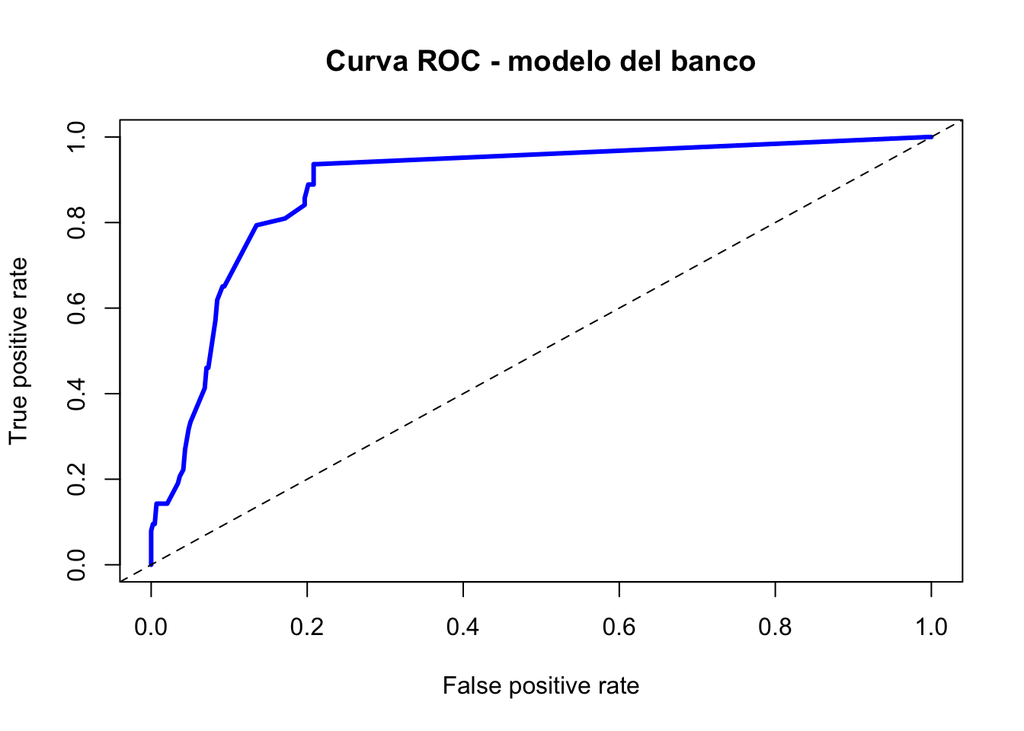

```r
pred <- prediction(predictions = prob_yes, labels = bank_test$y)
perf <- performance(pred, measure = "tpr", x.measure = "fpr")
plot(perf, main = "Curva ROC - modelo del banco", col = "blue", lwd = 3)
abline(a = 0, b = 1, lty = 2)
```

- Y el **AUC** (área bajo la curva):

```r
perf.auc <- performance(pred, measure = "auc")
unlist(perf.auc@y.values)
```

```
## [1] 0.8865098
```

- Un AUC bastante por encima de 0.5: el modelo discrimina razonablemente, aunque haya que mirar la sensibilidad.

# 6. Validación cruzada

- Por último, estimamos el desempeño futuro con **validación cruzada** *k-fold*. La idea: partir los datos en $k$ grupos; cada uno se usa una vez como prueba, entrenando con los $k-1$ restantes, y se promedian las medidas.
- Con `caret` es directo. Usamos $k=5$ para ahorrar tiempo, y acotamos la grilla de parámetros del C5.0 (probamos sin y con *boosting*, `trials` 1 y 10) para que corra rápido:

```r
set.seed(123)
ctrl <- trainControl(method = "cv", number = 5)
grid <- expand.grid(model = "tree", trials = c(1, 10), winnow = FALSE)
bank_treecv <- train(y ~ ., data = bank_train, method = "C5.0",
                     metric = "Kappa", trControl = ctrl, tuneGrid = grid)
bank_treecv
```

```
## C5.0
##
## 4500 samples
##   19 predictor
##    2 classes: 'no', 'yes'
##
## No pre-processing
## Resampling: Cross-Validated (5 fold)
## Summary of sample sizes: 3600, 3600, 3599, 3601, 3600
## Resampling results across tuning parameters:
##
##   trials  Accuracy   Kappa
##    1      0.8944469  0.4283358
##   10      0.9053372  0.4408523
##
## Tuning parameter 'model' was held constant at a value of tree
## Tuning
##  parameter 'winnow' was held constant at a value of FALSE
## Kappa was used to select the optimal model using the largest value.
## The final values used for the model were trials = 10, model = tree and winnow
##  = FALSE.
```

- `caret` elige automáticamente la mejor configuración según el kappa promedio en validación cruzada. Predecimos en prueba y evaluamos:

```r
bank_pred_treecv <- predict(bank_treecv, bank_test)
confusionMatrix(data = bank_pred_treecv, reference = bank_test$y, positive = "yes")
```

```
## Confusion Matrix and Statistics
##
##           Reference
## Prediction  no yes
##        no  421  39
##        yes  16  24
##
##                Accuracy : 0.89
##                  95% CI : (0.8592, 0.9161)
##     No Information Rate : 0.874
##     P-Value [Acc > NIR] : 0.155879
##
##                   Kappa : 0.4081
##
##  Mcnemar's Test P-Value : 0.003012
##
##             Sensitivity : 0.3810
##             Specificity : 0.9634
##          Pos Pred Value : 0.6000
##          Neg Pred Value : 0.9152
##              Prevalence : 0.1260
##          Detection Rate : 0.0480
##    Detection Prevalence : 0.0800
##       Balanced Accuracy : 0.6722
##
##        'Positive' Class : yes
##
```

- La validación cruzada da una estimación más robusta del desempeño y elige los hiperparámetros (aquí, si conviene activar el *boosting*). Aun así, el desbalance sigue siendo un reto —la sensibilidad sobre la clase minoritaria es baja—, y lo atacamos de frente en el taller de desbalance.

*Nota sobre los datos: `bank.csv` aquí es una muestra aleatoria de 5.000 registros (semilla 123) de la base UCI Bank Marketing (~41.000 registros), tomada para que los talleres corran rápido en clase conservando el desbalance de clase original (~11% de “yes”).*